# Risk Factor Analysis

## Outcome Variable

**Outcome Variable:** wast_rec90d

## Predictor Variables

**Intervention Variable:** nchldlt5

**Adjustment Set:**

unadjusted

## Stratifying Variables

The analysis was stratified on these variable(s):

- agecat
- studyid
- country

## Data Summary

| agecat | studyid | country | nchldlt5 | wast_rec90d | n_cell | n | outcome_variable |
| --- | --- | --- | --- | --- | --- | --- | --- |
| 0-24 months | ki1000108-IRC | INDIA | 1 | 0 | 39 | 395 | wast_rec90d |
| 0-24 months | ki1000108-IRC | INDIA | 1 | 1 | 56 | 395 | wast_rec90d |
| 0-24 months | ki1000108-IRC | INDIA | 2+ | 0 | 123 | 395 | wast_rec90d |
| 0-24 months | ki1000108-IRC | INDIA | 2+ | 1 | 177 | 395 | wast_rec90d |
| 0-24 months | ki1017093b-PROVIDE | BANGLADESH | 1 | 0 | 87 | 308 | wast_rec90d |
| 0-24 months | ki1017093b-PROVIDE | BANGLADESH | 1 | 1 | 138 | 308 | wast_rec90d |
| 0-24 months | ki1017093b-PROVIDE | BANGLADESH | 2+ | 0 | 42 | 308 | wast_rec90d |
| 0-24 months | ki1017093b-PROVIDE | BANGLADESH | 2+ | 1 | 41 | 308 | wast_rec90d |
| 0-24 months | ki1017093c-NIH-Crypto | BANGLADESH | 1 | 0 | 73 | 310 | wast_rec90d |
| 0-24 months | ki1017093c-NIH-Crypto | BANGLADESH | 1 | 1 | 136 | 310 | wast_rec90d |
| 0-24 months | ki1017093c-NIH-Crypto | BANGLADESH | 2+ | 0 | 44 | 310 | wast_rec90d |
| 0-24 months | ki1017093c-NIH-Crypto | BANGLADESH | 2+ | 1 | 57 | 310 | wast_rec90d |
| 0-24 months | ki1066203-TanzaniaChild2 | TANZANIA, UNITED REPUBLIC OF | 1 | 0 | 186 | 711 | wast_rec90d |
| 0-24 months | ki1066203-TanzaniaChild2 | TANZANIA, UNITED REPUBLIC OF | 1 | 1 | 315 | 711 | wast_rec90d |
| 0-24 months | ki1066203-TanzaniaChild2 | TANZANIA, UNITED REPUBLIC OF | 2+ | 0 | 80 | 711 | wast_rec90d |
| 0-24 months | ki1066203-TanzaniaChild2 | TANZANIA, UNITED REPUBLIC OF | 2+ | 1 | 130 | 711 | wast_rec90d |
| 0-24 months | ki1112895-iLiNS-Zinc | BURKINA FASO | 1 | 0 | 241 | 787 | wast_rec90d |
| 0-24 months | ki1112895-iLiNS-Zinc | BURKINA FASO | 1 | 1 | 10 | 787 | wast_rec90d |
| 0-24 months | ki1112895-iLiNS-Zinc | BURKINA FASO | 2+ | 0 | 512 | 787 | wast_rec90d |
| 0-24 months | ki1112895-iLiNS-Zinc | BURKINA FASO | 2+ | 1 | 24 | 787 | wast_rec90d |
| 0-24 months | ki1148112-LCNI-5 | MALAWI | 1 | 0 | 25 | 78 | wast_rec90d |
| 0-24 months | ki1148112-LCNI-5 | MALAWI | 1 | 1 | 6 | 78 | wast_rec90d |
| 0-24 months | ki1148112-LCNI-5 | MALAWI | 2+ | 0 | 40 | 78 | wast_rec90d |
| 0-24 months | ki1148112-LCNI-5 | MALAWI | 2+ | 1 | 7 | 78 | wast_rec90d |
| 0-24 months | kiGH5241-JiVitA-3 | BANGLADESH | 1 | 0 | 2739 | 7562 | wast_rec90d |
| 0-24 months | kiGH5241-JiVitA-3 | BANGLADESH | 1 | 1 | 2148 | 7562 | wast_rec90d |
| 0-24 months | kiGH5241-JiVitA-3 | BANGLADESH | 2+ | 0 | 1629 | 7562 | wast_rec90d |
| 0-24 months | kiGH5241-JiVitA-3 | BANGLADESH | 2+ | 1 | 1046 | 7562 | wast_rec90d |
| 0-6 months | ki1000108-IRC | INDIA | 1 | 0 | 20 | 240 | wast_rec90d |
| 0-6 months | ki1000108-IRC | INDIA | 1 | 1 | 37 | 240 | wast_rec90d |
| 0-6 months | ki1000108-IRC | INDIA | 2+ | 0 | 67 | 240 | wast_rec90d |
| 0-6 months | ki1000108-IRC | INDIA | 2+ | 1 | 116 | 240 | wast_rec90d |
| 0-6 months | ki1017093b-PROVIDE | BANGLADESH | 1 | 0 | 25 | 185 | wast_rec90d |
| 0-6 months | ki1017093b-PROVIDE | BANGLADESH | 1 | 1 | 115 | 185 | wast_rec90d |
| 0-6 months | ki1017093b-PROVIDE | BANGLADESH | 2+ | 0 | 15 | 185 | wast_rec90d |
| 0-6 months | ki1017093b-PROVIDE | BANGLADESH | 2+ | 1 | 30 | 185 | wast_rec90d |
| 0-6 months | ki1017093c-NIH-Crypto | BANGLADESH | 1 | 0 | 14 | 197 | wast_rec90d |
| 0-6 months | ki1017093c-NIH-Crypto | BANGLADESH | 1 | 1 | 124 | 197 | wast_rec90d |
| 0-6 months | ki1017093c-NIH-Crypto | BANGLADESH | 2+ | 0 | 7 | 197 | wast_rec90d |
| 0-6 months | ki1017093c-NIH-Crypto | BANGLADESH | 2+ | 1 | 52 | 197 | wast_rec90d |
| 0-6 months | ki1066203-TanzaniaChild2 | TANZANIA, UNITED REPUBLIC OF | 1 | 0 | 66 | 339 | wast_rec90d |
| 0-6 months | ki1066203-TanzaniaChild2 | TANZANIA, UNITED REPUBLIC OF | 1 | 1 | 170 | 339 | wast_rec90d |
| 0-6 months | ki1066203-TanzaniaChild2 | TANZANIA, UNITED REPUBLIC OF | 2+ | 0 | 35 | 339 | wast_rec90d |
| 0-6 months | ki1066203-TanzaniaChild2 | TANZANIA, UNITED REPUBLIC OF | 2+ | 1 | 68 | 339 | wast_rec90d |
| 0-6 months | ki1148112-LCNI-5 | MALAWI | 1 | 0 | 1 | 4 | wast_rec90d |
| 0-6 months | ki1148112-LCNI-5 | MALAWI | 1 | 1 | 0 | 4 | wast_rec90d |
| 0-6 months | ki1148112-LCNI-5 | MALAWI | 2+ | 0 | 3 | 4 | wast_rec90d |
| 0-6 months | ki1148112-LCNI-5 | MALAWI | 2+ | 1 | 0 | 4 | wast_rec90d |
| 0-6 months | kiGH5241-JiVitA-3 | BANGLADESH | 1 | 0 | 952 | 4730 | wast_rec90d |
| 0-6 months | kiGH5241-JiVitA-3 | BANGLADESH | 1 | 1 | 2148 | 4730 | wast_rec90d |
| 0-6 months | kiGH5241-JiVitA-3 | BANGLADESH | 2+ | 0 | 584 | 4730 | wast_rec90d |
| 0-6 months | kiGH5241-JiVitA-3 | BANGLADESH | 2+ | 1 | 1046 | 4730 | wast_rec90d |
| 6-24 months | ki1000108-IRC | INDIA | 1 | 0 | 19 | 155 | wast_rec90d |
| 6-24 months | ki1000108-IRC | INDIA | 1 | 1 | 19 | 155 | wast_rec90d |
| 6-24 months | ki1000108-IRC | INDIA | 2+ | 0 | 56 | 155 | wast_rec90d |
| 6-24 months | ki1000108-IRC | INDIA | 2+ | 1 | 61 | 155 | wast_rec90d |
| 6-24 months | ki1017093b-PROVIDE | BANGLADESH | 1 | 0 | 62 | 123 | wast_rec90d |
| 6-24 months | ki1017093b-PROVIDE | BANGLADESH | 1 | 1 | 23 | 123 | wast_rec90d |
| 6-24 months | ki1017093b-PROVIDE | BANGLADESH | 2+ | 0 | 27 | 123 | wast_rec90d |
| 6-24 months | ki1017093b-PROVIDE | BANGLADESH | 2+ | 1 | 11 | 123 | wast_rec90d |
| 6-24 months | ki1017093c-NIH-Crypto | BANGLADESH | 1 | 0 | 59 | 113 | wast_rec90d |
| 6-24 months | ki1017093c-NIH-Crypto | BANGLADESH | 1 | 1 | 12 | 113 | wast_rec90d |
| 6-24 months | ki1017093c-NIH-Crypto | BANGLADESH | 2+ | 0 | 37 | 113 | wast_rec90d |
| 6-24 months | ki1017093c-NIH-Crypto | BANGLADESH | 2+ | 1 | 5 | 113 | wast_rec90d |
| 6-24 months | ki1066203-TanzaniaChild2 | TANZANIA, UNITED REPUBLIC OF | 1 | 0 | 120 | 372 | wast_rec90d |
| 6-24 months | ki1066203-TanzaniaChild2 | TANZANIA, UNITED REPUBLIC OF | 1 | 1 | 145 | 372 | wast_rec90d |
| 6-24 months | ki1066203-TanzaniaChild2 | TANZANIA, UNITED REPUBLIC OF | 2+ | 0 | 45 | 372 | wast_rec90d |
| 6-24 months | ki1066203-TanzaniaChild2 | TANZANIA, UNITED REPUBLIC OF | 2+ | 1 | 62 | 372 | wast_rec90d |
| 6-24 months | ki1112895-iLiNS-Zinc | BURKINA FASO | 1 | 0 | 241 | 787 | wast_rec90d |
| 6-24 months | ki1112895-iLiNS-Zinc | BURKINA FASO | 1 | 1 | 10 | 787 | wast_rec90d |
| 6-24 months | ki1112895-iLiNS-Zinc | BURKINA FASO | 2+ | 0 | 512 | 787 | wast_rec90d |
| 6-24 months | ki1112895-iLiNS-Zinc | BURKINA FASO | 2+ | 1 | 24 | 787 | wast_rec90d |
| 6-24 months | ki1148112-LCNI-5 | MALAWI | 1 | 0 | 24 | 74 | wast_rec90d |
| 6-24 months | ki1148112-LCNI-5 | MALAWI | 1 | 1 | 6 | 74 | wast_rec90d |
| 6-24 months | ki1148112-LCNI-5 | MALAWI | 2+ | 0 | 37 | 74 | wast_rec90d |
| 6-24 months | ki1148112-LCNI-5 | MALAWI | 2+ | 1 | 7 | 74 | wast_rec90d |
| 6-24 months | kiGH5241-JiVitA-3 | BANGLADESH | 1 | 0 | 1787 | 2832 | wast_rec90d |
| 6-24 months | kiGH5241-JiVitA-3 | BANGLADESH | 1 | 1 | 0 | 2832 | wast_rec90d |
| 6-24 months | kiGH5241-JiVitA-3 | BANGLADESH | 2+ | 0 | 1045 | 2832 | wast_rec90d |
| 6-24 months | kiGH5241-JiVitA-3 | BANGLADESH | 2+ | 1 | 0 | 2832 | wast_rec90d |

The following strata were considered:

- agecat: 0-24 months, studyid: ki1000108-IRC, country: INDIA
- agecat: 0-24 months, studyid: ki1017093b-PROVIDE, country: BANGLADESH
- agecat: 0-24 months, studyid: ki1017093c-NIH-Crypto, country: BANGLADESH
- agecat: 0-24 months, studyid: ki1066203-TanzaniaChild2, country: TANZANIA, UNITED REPUBLIC OF
- agecat: 0-24 months, studyid: ki1112895-iLiNS-Zinc, country: BURKINA FASO
- agecat: 0-24 months, studyid: ki1148112-LCNI-5, country: MALAWI
- agecat: 0-24 months, studyid: kiGH5241-JiVitA-3, country: BANGLADESH
- agecat: 0-6 months, studyid: ki1000108-IRC, country: INDIA
- agecat: 0-6 months, studyid: ki1017093b-PROVIDE, country: BANGLADESH
- agecat: 0-6 months, studyid: ki1017093c-NIH-Crypto, country: BANGLADESH
- agecat: 0-6 months, studyid: ki1066203-TanzaniaChild2, country: TANZANIA, UNITED REPUBLIC OF
- agecat: 0-6 months, studyid: ki1148112-LCNI-5, country: MALAWI
- agecat: 0-6 months, studyid: kiGH5241-JiVitA-3, country: BANGLADESH
- agecat: 6-24 months, studyid: ki1000108-IRC, country: INDIA
- agecat: 6-24 months, studyid: ki1017093b-PROVIDE, country: BANGLADESH
- agecat: 6-24 months, studyid: ki1017093c-NIH-Crypto, country: BANGLADESH
- agecat: 6-24 months, studyid: ki1066203-TanzaniaChild2, country: TANZANIA, UNITED REPUBLIC OF
- agecat: 6-24 months, studyid: ki1112895-iLiNS-Zinc, country: BURKINA FASO
- agecat: 6-24 months, studyid: ki1148112-LCNI-5, country: MALAWI
- agecat: 6-24 months, studyid: kiGH5241-JiVitA-3, country: BANGLADESH

### Dropped Strata

Some strata were dropped due to rare outcomes:

- agecat: 0-6 months, studyid: ki1148112-LCNI-5, country: MALAWI
- agecat: 6-24 months, studyid: kiGH5241-JiVitA-3, country: BANGLADESH

## Methods Detail

We’re interested in the causal parameters $E[Y_a]$ for all values of $a \in \mathcal{A}$. These parameters represent the mean outcome if, possibly contrary to fact, we intervened to set all units to have $A=a$. Under the randomization and positivity assumptions, these are identified by the statistical parameters $\psi_a=E_W[E_{Y|A,W}(Y|A=a,W)]$. In addition, we’re interested in the mean of $Y$, $E[Y]$ under no intervention (the observed mean). We will estimate these parameters by using SuperLearner to fit the relevant likelihood factors – $E_{Y|A,W}(Y|A=a,W)$ and $p(A=a|W)$, and then updating our likelihood fit using a joint TMLE.

For unadjusted analyses ($W=\{\}$), initial likelihoods were estimated using Lrnr_glm to estimate the simple $E(Y|A)$ and Lrnr_mean to estimate $p(A)$. For adjusted analyses, a small library containing Lrnr_glmnet, Lrnr_xgboost, and Lrnr_mean was used.

Having estimated these parameters, we will then use the delta method to estimate relative risks and attributable risks relative to a prespecified baseline level of $A$.

# Results Detail

## Results Plots

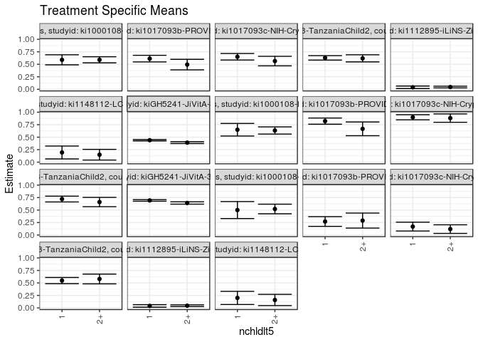

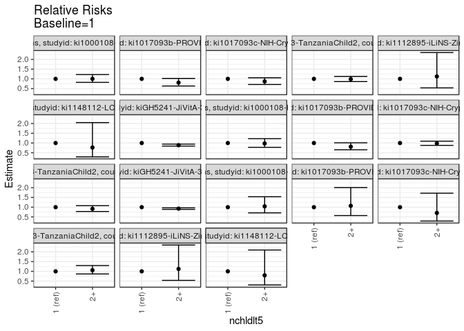

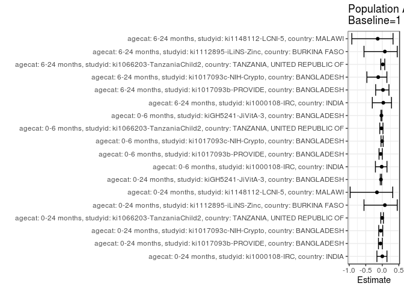

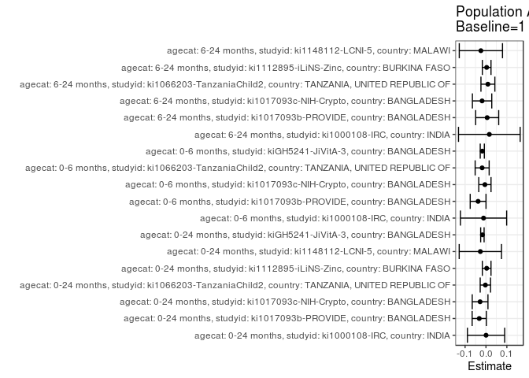

## Results Table

### Parameter: TSM

| agecat | studyid | country | intervention_level | baseline_level | estimate | ci_lower | ci_upper |
| --- | --- | --- | --- | --- | --- | --- | --- |
| 0-24 months | ki1000108-IRC | INDIA | 1 | NA | 0.5894737 | 0.4891290 | 0.6898183 |
| 0-24 months | ki1000108-IRC | INDIA | 2+ | NA | 0.5900000 | 0.5290875 | 0.6509125 |
| 0-24 months | ki1017093b-PROVIDE | BANGLADESH | 1 | NA | 0.6133333 | 0.5472271 | 0.6794396 |
| 0-24 months | ki1017093b-PROVIDE | BANGLADESH | 2+ | NA | 0.4939759 | 0.3886688 | 0.5992831 |
| 0-24 months | ki1017093c-NIH-Crypto | BANGLADESH | 1 | NA | 0.6507177 | 0.5852924 | 0.7161430 |
| 0-24 months | ki1017093c-NIH-Crypto | BANGLADESH | 2+ | NA | 0.5643564 | 0.4689899 | 0.6597230 |
| 0-24 months | ki1066203-TanzaniaChild2 | TANZANIA, UNITED REPUBLIC OF | 1 | NA | 0.6287425 | 0.5842394 | 0.6732457 |
| 0-24 months | ki1066203-TanzaniaChild2 | TANZANIA, UNITED REPUBLIC OF | 2+ | NA | 0.6190476 | 0.5480292 | 0.6900660 |
| 0-24 months | ki1112895-iLiNS-Zinc | BURKINA FASO | 1 | NA | 0.0398406 | 0.0146536 | 0.0650277 |
| 0-24 months | ki1112895-iLiNS-Zinc | BURKINA FASO | 2+ | NA | 0.0447761 | 0.0276905 | 0.0618617 |
| 0-24 months | ki1148112-LCNI-5 | MALAWI | 1 | NA | 0.1935484 | 0.0643859 | 0.3227109 |
| 0-24 months | ki1148112-LCNI-5 | MALAWI | 2+ | NA | 0.1489362 | 0.0421700 | 0.2557024 |
| 0-24 months | kiGH5241-JiVitA-3 | BANGLADESH | 1 | NA | 0.4395335 | 0.4256234 | 0.4534435 |
| 0-24 months | kiGH5241-JiVitA-3 | BANGLADESH | 2+ | NA | 0.3910280 | 0.3725648 | 0.4094913 |
| 0-6 months | ki1000108-IRC | INDIA | 1 | NA | 0.6491228 | 0.5229840 | 0.7752616 |
| 0-6 months | ki1000108-IRC | INDIA | 2+ | NA | 0.6338798 | 0.5621518 | 0.7056077 |
| 0-6 months | ki1017093b-PROVIDE | BANGLADESH | 1 | NA | 0.8214286 | 0.7593450 | 0.8835121 |
| 0-6 months | ki1017093b-PROVIDE | BANGLADESH | 2+ | NA | 0.6666667 | 0.5292770 | 0.8040564 |
| 0-6 months | ki1017093c-NIH-Crypto | BANGLADESH | 1 | NA | 0.8985507 | 0.8475715 | 0.9495299 |
| 0-6 months | ki1017093c-NIH-Crypto | BANGLADESH | 2+ | NA | 0.8813559 | 0.7977824 | 0.9649295 |
| 0-6 months | ki1066203-TanzaniaChild2 | TANZANIA, UNITED REPUBLIC OF | 1 | NA | 0.7203390 | 0.6623642 | 0.7783138 |
| 0-6 months | ki1066203-TanzaniaChild2 | TANZANIA, UNITED REPUBLIC OF | 2+ | NA | 0.6601942 | 0.5668889 | 0.7534995 |
| 0-6 months | kiGH5241-JiVitA-3 | BANGLADESH | 1 | NA | 0.6929032 | 0.6766629 | 0.7091435 |
| 0-6 months | kiGH5241-JiVitA-3 | BANGLADESH | 2+ | NA | 0.6417178 | 0.6184440 | 0.6649916 |
| 6-24 months | ki1000108-IRC | INDIA | 1 | NA | 0.5000000 | 0.3298550 | 0.6701450 |
| 6-24 months | ki1000108-IRC | INDIA | 2+ | NA | 0.5213675 | 0.4249456 | 0.6177894 |
| 6-24 months | ki1017093b-PROVIDE | BANGLADESH | 1 | NA | 0.2705882 | 0.1738315 | 0.3673450 |
| 6-24 months | ki1017093b-PROVIDE | BANGLADESH | 2+ | NA | 0.2894737 | 0.1394666 | 0.4394808 |
| 6-24 months | ki1017093c-NIH-Crypto | BANGLADESH | 1 | NA | 0.1690141 | 0.0805585 | 0.2574696 |
| 6-24 months | ki1017093c-NIH-Crypto | BANGLADESH | 2+ | NA | 0.1190476 | 0.0331409 | 0.2049543 |
| 6-24 months | ki1066203-TanzaniaChild2 | TANZANIA, UNITED REPUBLIC OF | 1 | NA | 0.5471698 | 0.4853724 | 0.6089672 |
| 6-24 months | ki1066203-TanzaniaChild2 | TANZANIA, UNITED REPUBLIC OF | 2+ | NA | 0.5794392 | 0.4815130 | 0.6773655 |
| 6-24 months | ki1112895-iLiNS-Zinc | BURKINA FASO | 1 | NA | 0.0398406 | 0.0146536 | 0.0650277 |
| 6-24 months | ki1112895-iLiNS-Zinc | BURKINA FASO | 2+ | NA | 0.0447761 | 0.0276905 | 0.0618617 |
| 6-24 months | ki1148112-LCNI-5 | MALAWI | 1 | NA | 0.2000000 | 0.0680734 | 0.3319266 |
| 6-24 months | ki1148112-LCNI-5 | MALAWI | 2+ | NA | 0.1590909 | 0.0462498 | 0.2719320 |

### Parameter: E(Y)

| agecat | studyid | country | intervention_level | baseline_level | estimate | ci_lower | ci_upper |
| --- | --- | --- | --- | --- | --- | --- | --- |
| 0-24 months | ki1000108-IRC | INDIA | NA | NA | 0.5898734 | 0.5376978 | 0.6420491 |
| 0-24 months | ki1017093b-PROVIDE | BANGLADESH | NA | NA | 0.5811688 | 0.5245443 | 0.6377934 |
| 0-24 months | ki1017093c-NIH-Crypto | BANGLADESH | NA | NA | 0.6225806 | 0.5684562 | 0.6767051 |
| 0-24 months | ki1066203-TanzaniaChild2 | TANZANIA, UNITED REPUBLIC OF | NA | NA | 0.6258790 | 0.5881498 | 0.6636083 |
| 0-24 months | ki1112895-iLiNS-Zinc | BURKINA FASO | NA | NA | 0.0432020 | 0.0290622 | 0.0573419 |
| 0-24 months | ki1148112-LCNI-5 | MALAWI | NA | NA | 0.1666667 | 0.0842830 | 0.2490503 |
| 0-24 months | kiGH5241-JiVitA-3 | BANGLADESH | NA | NA | 0.4223750 | 0.4112475 | 0.4335026 |
| 0-6 months | ki1000108-IRC | INDIA | NA | NA | 0.6375000 | 0.5751450 | 0.6998550 |
| 0-6 months | ki1017093b-PROVIDE | BANGLADESH | NA | NA | 0.7837838 | 0.7252863 | 0.8422812 |
| 0-6 months | ki1017093c-NIH-Crypto | BANGLADESH | NA | NA | 0.8934010 | 0.8497799 | 0.9370221 |
| 0-6 months | ki1066203-TanzaniaChild2 | TANZANIA, UNITED REPUBLIC OF | NA | NA | 0.7020649 | 0.6526590 | 0.7514708 |
| 0-6 months | kiGH5241-JiVitA-3 | BANGLADESH | NA | NA | 0.6752643 | 0.6619190 | 0.6886095 |
| 6-24 months | ki1000108-IRC | INDIA | NA | NA | 0.5161290 | 0.4322562 | 0.6000019 |
| 6-24 months | ki1017093b-PROVIDE | BANGLADESH | NA | NA | 0.2764228 | 0.1950773 | 0.3577682 |
| 6-24 months | ki1017093c-NIH-Crypto | BANGLADESH | NA | NA | 0.1504425 | 0.0860251 | 0.2148599 |
| 6-24 months | ki1066203-TanzaniaChild2 | TANZANIA, UNITED REPUBLIC OF | NA | NA | 0.5564516 | 0.5041613 | 0.6087419 |
| 6-24 months | ki1112895-iLiNS-Zinc | BURKINA FASO | NA | NA | 0.0432020 | 0.0290622 | 0.0573419 |
| 6-24 months | ki1148112-LCNI-5 | MALAWI | NA | NA | 0.1756757 | 0.0897916 | 0.2615597 |

### Parameter: RR

| agecat | studyid | country | intervention_level | baseline_level | estimate | ci_lower | ci_upper |
| --- | --- | --- | --- | --- | --- | --- | --- |
| 0-24 months | ki1000108-IRC | INDIA | 1 | 1 | 1.0000000 | 1.0000000 | 1.0000000 |
| 0-24 months | ki1000108-IRC | INDIA | 2+ | 1 | 1.0008929 | 0.8201978 | 1.2213963 |
| 0-24 months | ki1017093b-PROVIDE | BANGLADESH | 1 | 1 | 1.0000000 | 1.0000000 | 1.0000000 |
| 0-24 months | ki1017093b-PROVIDE | BANGLADESH | 2+ | 1 | 0.8053955 | 0.6342665 | 1.0226962 |
| 0-24 months | ki1017093c-NIH-Crypto | BANGLADESH | 1 | 1 | 1.0000000 | 1.0000000 | 1.0000000 |
| 0-24 months | ki1017093c-NIH-Crypto | BANGLADESH | 2+ | 1 | 0.8672831 | 0.7122359 | 1.0560825 |
| 0-24 months | ki1066203-TanzaniaChild2 | TANZANIA, UNITED REPUBLIC OF | 1 | 1 | 1.0000000 | 1.0000000 | 1.0000000 |
| 0-24 months | ki1066203-TanzaniaChild2 | TANZANIA, UNITED REPUBLIC OF | 2+ | 1 | 0.9845805 | 0.8604126 | 1.1266674 |
| 0-24 months | ki1112895-iLiNS-Zinc | BURKINA FASO | 1 | 1 | 1.0000000 | 1.0000000 | 1.0000000 |
| 0-24 months | ki1112895-iLiNS-Zinc | BURKINA FASO | 2+ | 1 | 1.1238806 | 0.5370664 | 2.3518650 |
| 0-24 months | ki1148112-LCNI-5 | MALAWI | 1 | 1 | 1.0000000 | 1.0000000 | 1.0000000 |
| 0-24 months | ki1148112-LCNI-5 | MALAWI | 2+ | 1 | 0.7695035 | 0.2889550 | 2.0492314 |
| 0-24 months | kiGH5241-JiVitA-3 | BANGLADESH | 1 | 1 | 1.0000000 | 1.0000000 | 1.0000000 |
| 0-24 months | kiGH5241-JiVitA-3 | BANGLADESH | 2+ | 1 | 0.8896434 | 0.8404846 | 0.9416775 |
| 0-6 months | ki1000108-IRC | INDIA | 1 | 1 | 1.0000000 | 1.0000000 | 1.0000000 |
| 0-6 months | ki1000108-IRC | INDIA | 2+ | 1 | 0.9765175 | 0.7798511 | 1.2227801 |
| 0-6 months | ki1017093b-PROVIDE | BANGLADESH | 1 | 1 | 1.0000000 | 1.0000000 | 1.0000000 |
| 0-6 months | ki1017093b-PROVIDE | BANGLADESH | 2+ | 1 | 0.8115942 | 0.6516379 | 1.0108146 |
| 0-6 months | ki1017093c-NIH-Crypto | BANGLADESH | 1 | 1 | 1.0000000 | 1.0000000 | 1.0000000 |
| 0-6 months | ki1017093c-NIH-Crypto | BANGLADESH | 2+ | 1 | 0.9808639 | 0.8782515 | 1.0954652 |
| 0-6 months | ki1066203-TanzaniaChild2 | TANZANIA, UNITED REPUBLIC OF | 1 | 1 | 1.0000000 | 1.0000000 | 1.0000000 |
| 0-6 months | ki1066203-TanzaniaChild2 | TANZANIA, UNITED REPUBLIC OF | 2+ | 1 | 0.9165049 | 0.7789331 | 1.0783739 |
| 0-6 months | kiGH5241-JiVitA-3 | BANGLADESH | 1 | 1 | 1.0000000 | 1.0000000 | 1.0000000 |
| 0-6 months | kiGH5241-JiVitA-3 | BANGLADESH | 2+ | 1 | 0.9261290 | 0.8869879 | 0.9669974 |
| 6-24 months | ki1000108-IRC | INDIA | 1 | 1 | 1.0000000 | 1.0000000 | 1.0000000 |
| 6-24 months | ki1000108-IRC | INDIA | 2+ | 1 | 1.0427350 | 0.7078288 | 1.5361008 |
| 6-24 months | ki1017093b-PROVIDE | BANGLADESH | 1 | 1 | 1.0000000 | 1.0000000 | 1.0000000 |
| 6-24 months | ki1017093b-PROVIDE | BANGLADESH | 2+ | 1 | 1.0697941 | 0.5699484 | 2.0080052 |
| 6-24 months | ki1017093c-NIH-Crypto | BANGLADESH | 1 | 1 | 1.0000000 | 1.0000000 | 1.0000000 |
| 6-24 months | ki1017093c-NIH-Crypto | BANGLADESH | 2+ | 1 | 0.7043651 | 0.2888063 | 1.7178646 |
| 6-24 months | ki1066203-TanzaniaChild2 | TANZANIA, UNITED REPUBLIC OF | 1 | 1 | 1.0000000 | 1.0000000 | 1.0000000 |
| 6-24 months | ki1066203-TanzaniaChild2 | TANZANIA, UNITED REPUBLIC OF | 2+ | 1 | 1.0589752 | 0.8641817 | 1.2976767 |
| 6-24 months | ki1112895-iLiNS-Zinc | BURKINA FASO | 1 | 1 | 1.0000000 | 1.0000000 | 1.0000000 |
| 6-24 months | ki1112895-iLiNS-Zinc | BURKINA FASO | 2+ | 1 | 1.1238806 | 0.5370664 | 2.3518650 |
| 6-24 months | ki1148112-LCNI-5 | MALAWI | 1 | 1 | 1.0000000 | 1.0000000 | 1.0000000 |
| 6-24 months | ki1148112-LCNI-5 | MALAWI | 2+ | 1 | 0.7954545 | 0.3019242 | 2.0957182 |

### Parameter: PAR

| agecat | studyid | country | intervention_level | baseline_level | estimate | ci_lower | ci_upper |
| --- | --- | --- | --- | --- | --- | --- | --- |
| 0-24 months | ki1000108-IRC | INDIA | 1 | NA | 0.0003997 | -0.0887607 | 0.0895602 |
| 0-24 months | ki1017093b-PROVIDE | BANGLADESH | 1 | NA | -0.0321645 | -0.0661697 | 0.0018407 |
| 0-24 months | ki1017093c-NIH-Crypto | BANGLADESH | 1 | NA | -0.0281371 | -0.0657790 | 0.0095048 |
| 0-24 months | ki1066203-TanzaniaChild2 | TANZANIA, UNITED REPUBLIC OF | 1 | NA | -0.0028635 | -0.0276255 | 0.0218985 |
| 0-24 months | ki1112895-iLiNS-Zinc | BURKINA FASO | 1 | NA | 0.0033614 | -0.0173674 | 0.0240902 |
| 0-24 months | ki1148112-LCNI-5 | MALAWI | 1 | NA | -0.0268817 | -0.1281436 | 0.0743802 |
| 0-24 months | kiGH5241-JiVitA-3 | BANGLADESH | 1 | NA | -0.0171584 | -0.0253580 | -0.0089589 |
| 0-6 months | ki1000108-IRC | INDIA | 1 | NA | -0.0116228 | -0.1223037 | 0.0990581 |
| 0-6 months | ki1017093b-PROVIDE | BANGLADESH | 1 | NA | -0.0376448 | -0.0754820 | 0.0001924 |
| 0-6 months | ki1017093c-NIH-Crypto | BANGLADESH | 1 | NA | -0.0051497 | -0.0344911 | 0.0241917 |
| 0-6 months | ki1066203-TanzaniaChild2 | TANZANIA, UNITED REPUBLIC OF | 1 | NA | -0.0182741 | -0.0518091 | 0.0152609 |
| 0-6 months | kiGH5241-JiVitA-3 | BANGLADESH | 1 | NA | -0.0176390 | -0.0274433 | -0.0078346 |
| 6-24 months | ki1000108-IRC | INDIA | 1 | NA | 0.0161290 | -0.1314835 | 0.1637416 |
| 6-24 months | ki1017093b-PROVIDE | BANGLADESH | 1 | NA | 0.0058345 | -0.0492950 | 0.0609641 |
| 6-24 months | ki1017093c-NIH-Crypto | BANGLADESH | 1 | NA | -0.0185716 | -0.0649036 | 0.0277604 |
| 6-24 months | ki1066203-TanzaniaChild2 | TANZANIA, UNITED REPUBLIC OF | 1 | NA | 0.0092818 | -0.0240444 | 0.0426080 |
| 6-24 months | ki1112895-iLiNS-Zinc | BURKINA FASO | 1 | NA | 0.0033614 | -0.0173674 | 0.0240902 |
| 6-24 months | ki1148112-LCNI-5 | MALAWI | 1 | NA | -0.0243243 | -0.1278155 | 0.0791669 |

### Parameter: PAF

| agecat | studyid | country | intervention_level | baseline_level | estimate | ci_lower | ci_upper |
| --- | --- | --- | --- | --- | --- | --- | --- |
| 0-24 months | ki1000108-IRC | INDIA | 1 | NA | 0.0006777 | -0.1624997 | 0.1409502 |
| 0-24 months | ki1017093b-PROVIDE | BANGLADESH | 1 | NA | -0.0553445 | -0.1157599 | 0.0017996 |
| 0-24 months | ki1017093c-NIH-Crypto | BANGLADESH | 1 | NA | -0.0451942 | -0.1076406 | 0.0137315 |
| 0-24 months | ki1066203-TanzaniaChild2 | TANZANIA, UNITED REPUBLIC OF | 1 | NA | -0.0045751 | -0.0449377 | 0.0342284 |
| 0-24 months | ki1112895-iLiNS-Zinc | BURKINA FASO | 1 | NA | 0.0778064 | -0.5530935 | 0.4524213 |
| 0-24 months | ki1148112-LCNI-5 | MALAWI | 1 | NA | -0.1612903 | -0.9712387 | 0.3158641 |
| 0-24 months | kiGH5241-JiVitA-3 | BANGLADESH | 1 | NA | -0.0406237 | -0.0602343 | -0.0213757 |
| 0-6 months | ki1000108-IRC | INDIA | 1 | NA | -0.0182319 | -0.2075746 | 0.1414227 |
| 0-6 months | ki1017093b-PROVIDE | BANGLADESH | 1 | NA | -0.0480296 | -0.0984114 | 0.0000414 |
| 0-6 months | ki1017093c-NIH-Crypto | BANGLADESH | 1 | NA | -0.0057642 | -0.0391686 | 0.0265665 |
| 0-6 months | ki1066203-TanzaniaChild2 | TANZANIA, UNITED REPUBLIC OF | 1 | NA | -0.0260291 | -0.0750795 | 0.0207835 |
| 0-6 months | kiGH5241-JiVitA-3 | BANGLADESH | 1 | NA | -0.0261216 | -0.0407743 | -0.0116751 |
| 6-24 months | ki1000108-IRC | INDIA | 1 | NA | 0.0312500 | -0.3015416 | 0.2789500 |
| 6-24 months | ki1017093b-PROVIDE | BANGLADESH | 1 | NA | 0.0211073 | -0.1999704 | 0.2014545 |
| 6-24 months | ki1017093c-NIH-Crypto | BANGLADESH | 1 | NA | -0.1234466 | -0.4658052 | 0.1389496 |
| 6-24 months | ki1066203-TanzaniaChild2 | TANZANIA, UNITED REPUBLIC OF | 1 | NA | 0.0166803 | -0.0450811 | 0.0747918 |
| 6-24 months | ki1112895-iLiNS-Zinc | BURKINA FASO | 1 | NA | 0.0778064 | -0.5530935 | 0.4524213 |
| 6-24 months | ki1148112-LCNI-5 | MALAWI | 1 | NA | -0.1384615 | -0.9209109 | 0.3252708 |